# Differential Binding Site Results for GSE95632

Mengyuan Kan (mengykan@upenn.edu)

22 October, 2018

MACS2 (2.1.1) function callpeak was used to call peaks. Peaks within blacklisted regions were filtered out.

DiffBind (2.6.6) was used for differential binding site analaysis, based on the the phenotype file provided. Normalized counts are saved in the following text file:

> GSE95632_Condition1_vs_Condition0_counts_normalized_by_diffbind.csv

Differential binding site analysis was done for all comparisons provided in the comparisons file, using DESeq2 by default.

Peaks were annotated using corresponding R packages org.Hs.eg.db and TxDb.Hsapiens.UCSC.hg38.knownGene by ChIPseeker (1.14.2).

Create bam read columns

Create bam control columns

Create peak bed columns

## GR_dex vs. GR_EtOH

### Samples in this comparison

Prepare diffbind csv input file

| SampleID | Tissue | Factor | Condition | Treatment | Replicate | bamReads | ControlID | bamControl | Peaks | PeakCaller |
| --- | --- | --- | --- | --- | --- | --- | --- | --- | --- | --- |
| SRR5309351 | ASM | GR | cond0 | EtOH | 1 | /home/mengykan/Projects/GSE95632/SRR5309351/bwa_out/SRR5309351.bam | SRR5309352 | /home/mengykan/Projects/GSE95632/SRR5309352/bwa_out/SRR5309352.bam | /home/mengykan/Projects/GSE95632/SRR5309351/macs2_out/SRR5309351.blackfilt.bed | bed |
| SRR5309353 | ASM | GR | cond0 | EtOH | 2 | /home/mengykan/Projects/GSE95632/SRR5309353/bwa_out/SRR5309353.bam | SRR5309352 | /home/mengykan/Projects/GSE95632/SRR5309352/bwa_out/SRR5309352.bam | /home/mengykan/Projects/GSE95632/SRR5309353/macs2_out/SRR5309353.blackfilt.bed | bed |
| SRR5309354 | ASM | GR | cond1 | Dex | 1 | /home/mengykan/Projects/GSE95632/SRR5309354/bwa_out/SRR5309354.bam | SRR5309355 | /home/mengykan/Projects/GSE95632/SRR5309355/bwa_out/SRR5309355.bam | /home/mengykan/Projects/GSE95632/SRR5309354/macs2_out/SRR5309354.blackfilt.bed | bed |
| SRR5309356 | ASM | GR | cond1 | Dex | 2 | /home/mengykan/Projects/GSE95632/SRR5309356/bwa_out/SRR5309356.bam | SRR5309355 | /home/mengykan/Projects/GSE95632/SRR5309355/bwa_out/SRR5309355.bam | /home/mengykan/Projects/GSE95632/SRR5309356/macs2_out/SRR5309356.blackfilt.bed | bed |

#### Major steps

1. Perform differential binding site analysis.
2. Annotate gene regions to peaks
3. Save differential results and count matrix for significant binding sites

### Top 50 differential binding sites by p-value

| Chr | Start | End | Conc | Fold | p.value | FDR | Annotation | Gene |
| --- | --- | --- | --- | --- | --- | --- | --- | --- |
| chr6 | 35725256 | 35728606 | 9.6 | 4.44 | 9.93e-140 | 3.88e-135 | Promoter | FKBP5 |
| chr10 | 74055718 | 74057256 | 9.37 | 4.27 | 2e-127 | 3.9e-123 | Intron | VCL |
| chr11 | 114179012 | 114180009 | 9.48 | 5.69 | 4.08e-124 | 5.31e-120 | Intron | ZBTB16 |
| chr2 | 121500835 | 121503083 | 9.32 | 3.74 | 1.26e-105 | 1.23e-101 | Intron | CLASP1 |
| chr2 | 20438296 | 20439356 | 8.81 | 4.33 | 2.75e-103 | 2.14e-99 | Distal Intergenic | RHOB |
| chr13 | 40235130 | 40237257 | 8.93 | 3.68 | 1.06e-101 | 6.9e-98 | Intron | LINC00548 |
| chr11 | 114154030 | 114155286 | 8.86 | 4.49 | 2.33e-101 | 1.3e-97 | Intron | ZBTB16 |
| chr11 | 114162303 | 114164603 | 9.07 | 3.82 | 1.03e-96 | 5.01e-93 | Intron | ZBTB16 |
| chr6 | 158706332 | 158708572 | 8.84 | 4.01 | 1.62e-95 | 7.02e-92 | Exon | SYTL3 |
| chr16 | 72989308 | 72990807 | 8.69 | 4.19 | 4.92e-95 | 1.92e-91 | Intron | ZFHX3 |

[output cut: 40 more lines]

### Description of annotated DiffBind output

Table above shows the selected columns. Here is the description of the full output:

| Output Column | Description |
| --- | --- |
| Chr | Chromosome of binding site |
| Start | Starting base position of binding site |
| End | End base position of binding site |
| Conc | Concentration - mean (log) reads across all samples in both groups |
| Conc_group1 | Group 1 Concentration - mean (log) reads across all samples first group |
| Conc_group2 | Group 2 Concentration - mean (log) reads across all samples in second group |
| Fold | Fold difference - mean fold difference of binding affinity of group 1 over group 2 (Conc1 - Conc2). |
| p.value | p-value calculation - statistic indicating significance of difference |
| FDR | adjusted p-value calculation - p-value subjected to multiple-testing correction |
| Annotation | Main type of genomic feature of the peak, including Promoter, 3' UTR, 5' UTR, Intron, Exon, Distal Intergenic, Downstream |

[output cut: 5 more lines]

### Volcano plots

Volcano plot (probes with a q-value <0.05 are present in red)

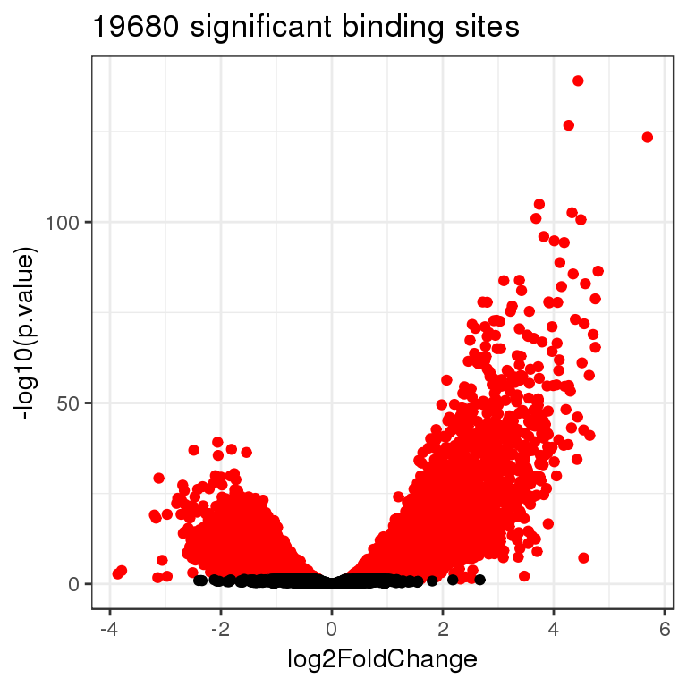

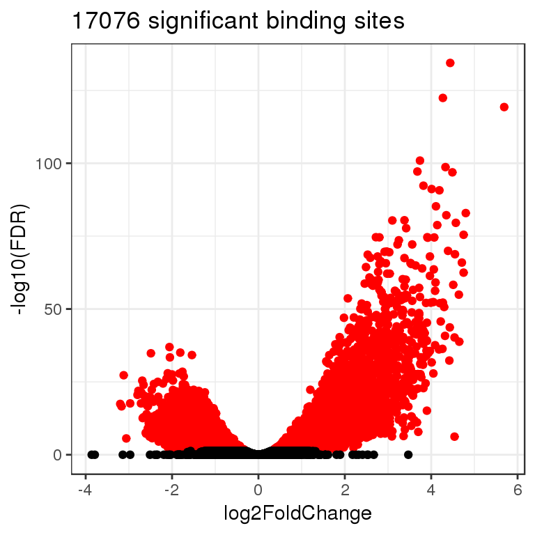

### MA plot

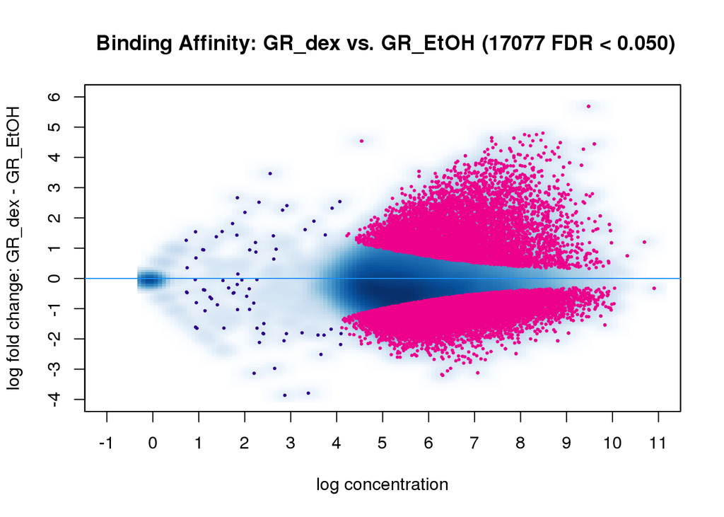

### Dendrogram based on log2 normalized data

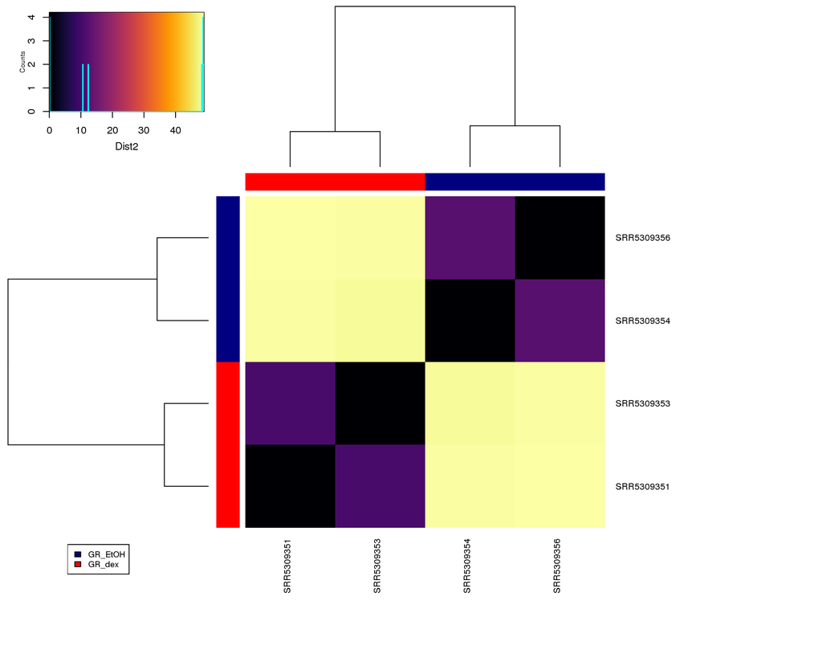

### Heatmaps for top 30 significant binding sites

Binding sites were ranked by adjusted p-values.

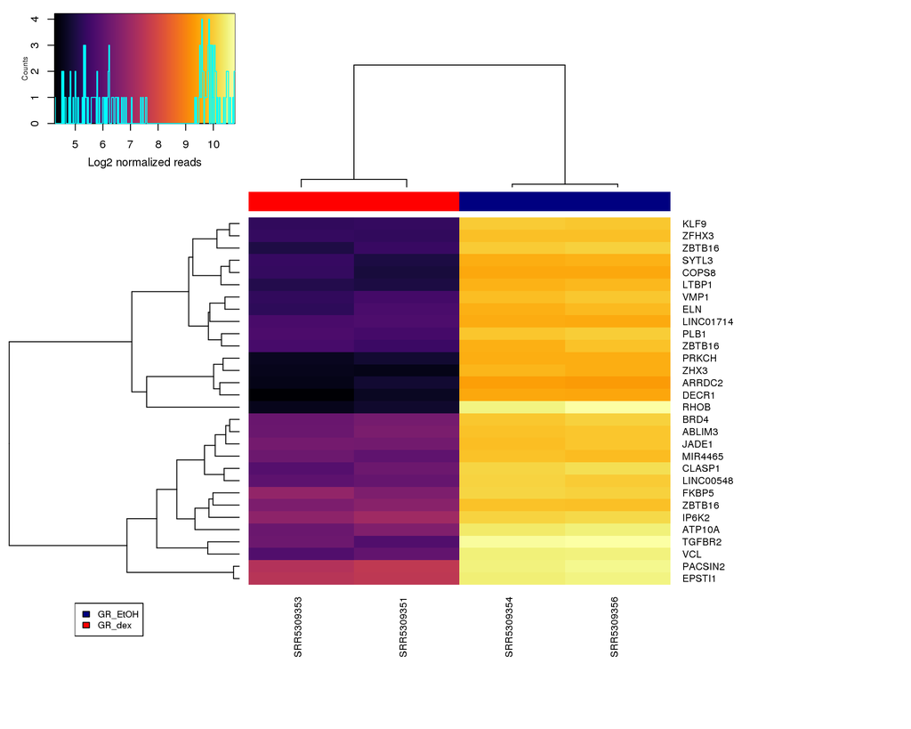

### Principal Component Analysis (PCA) Plot

Compute PCs and variance explained by the first 10 PCs

Variance explained

| PC | Proportion of Variance (%) | Cumulative Proportion of Variance (%) |
| --- | --- | --- |
| PC1 | 84.16 | 84.16 |
| PC2 | 15.35 | 99.51 |
| PC3 | 0.2883 | 99.79 |
| PC4 | 0.2063 | 100 |

PCA plots are generated using the first two principle components colored by known factors (e.g. Status, Tissue, or Donor)

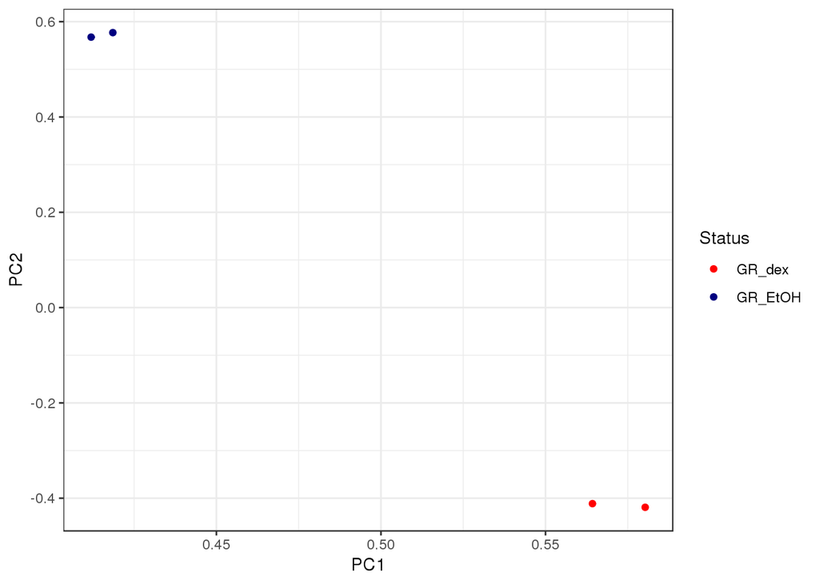

### Boxplots for top 20 differentially binding sites

Binding sites were ranked by pvalue. Counts have been normalized by sequencing depth. Apply log2-transformed values from plotting.

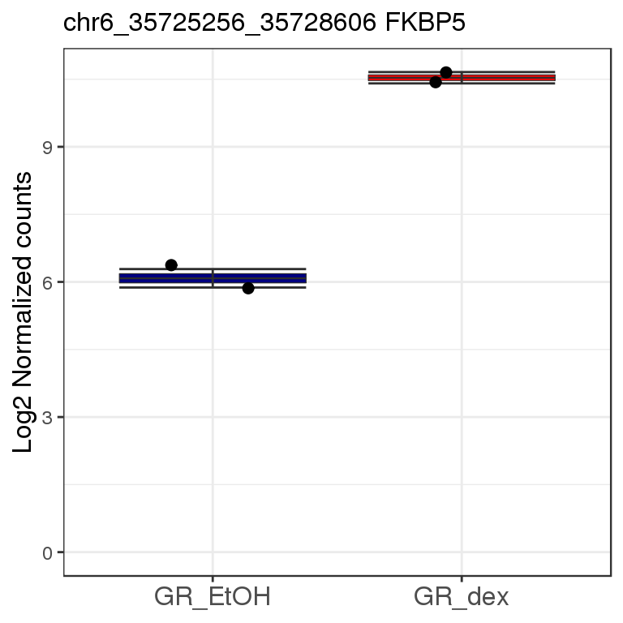

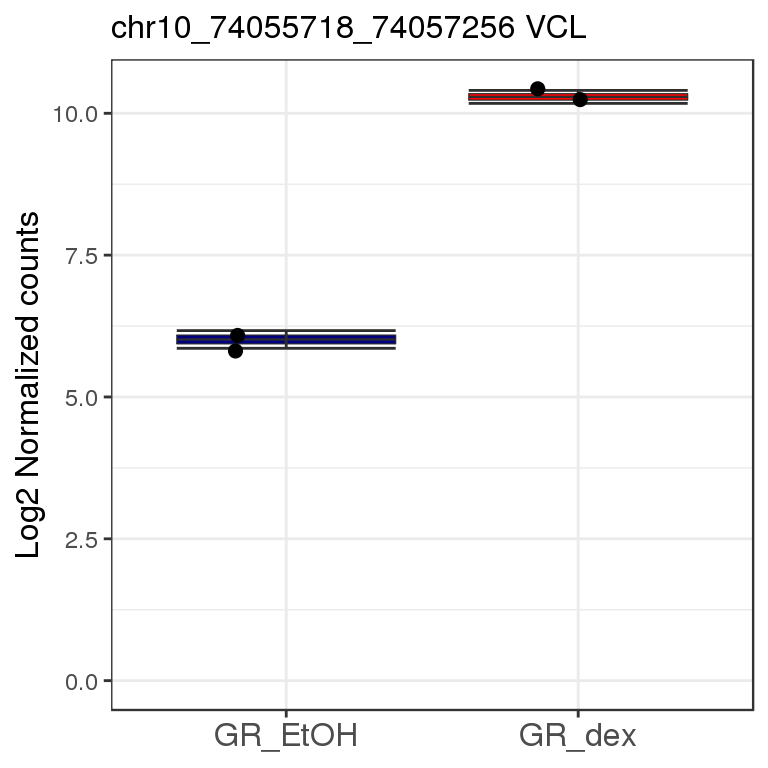

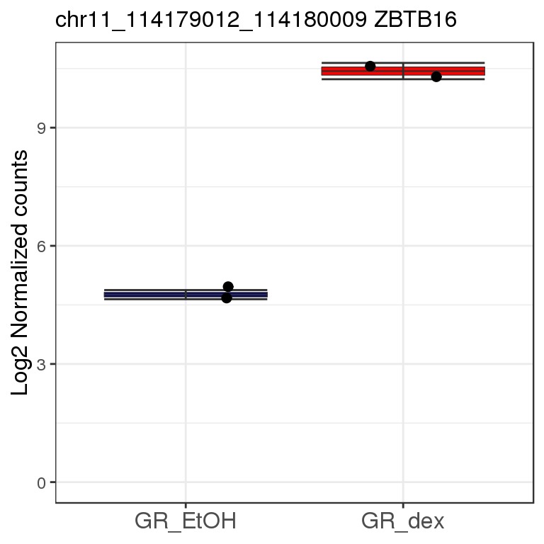

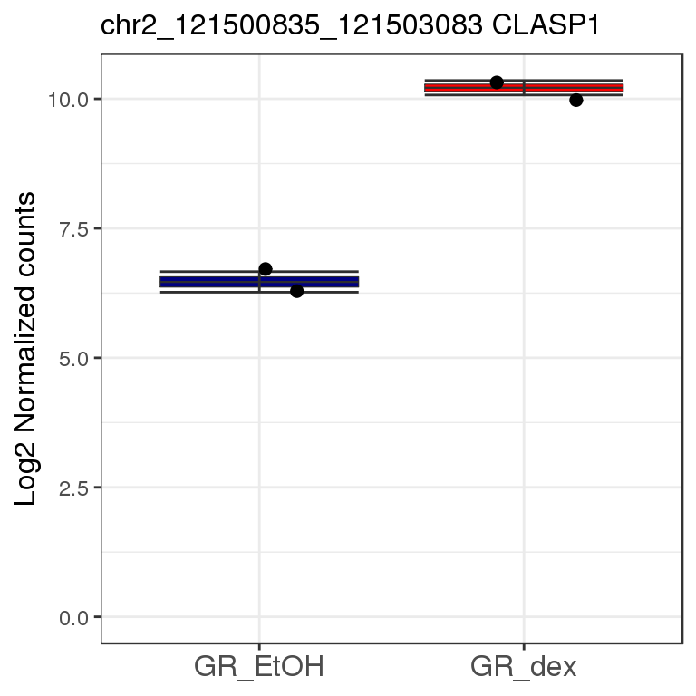

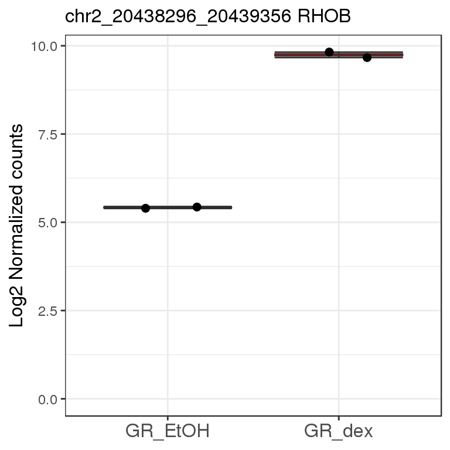

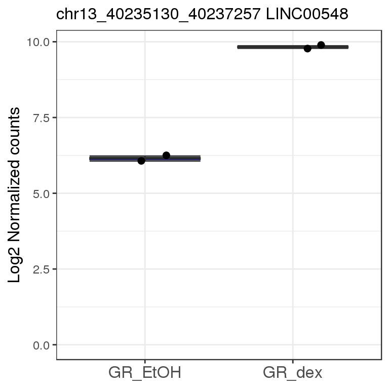

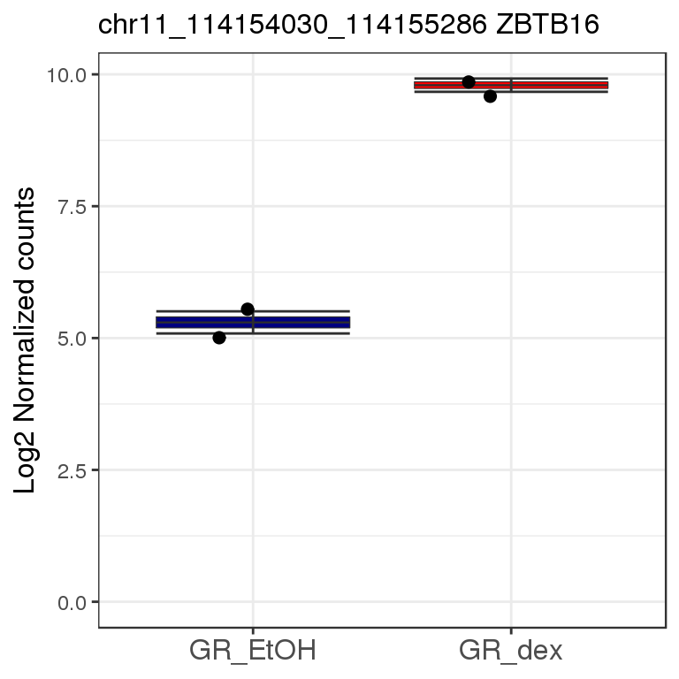

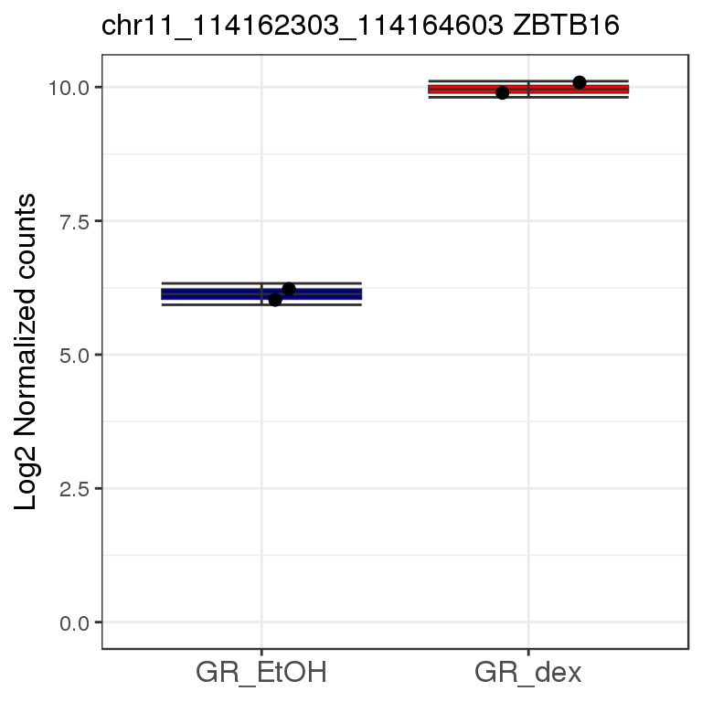

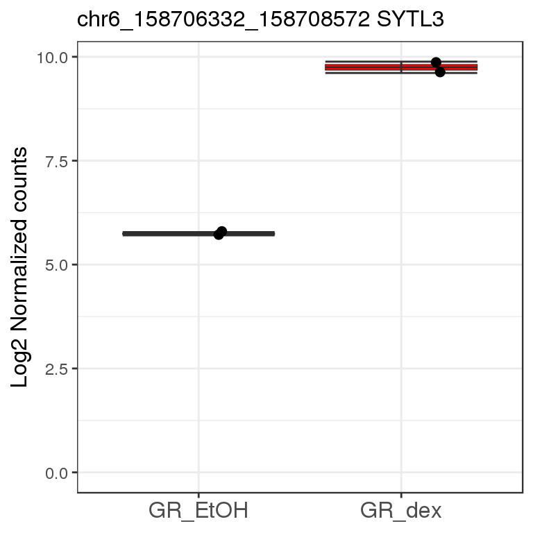

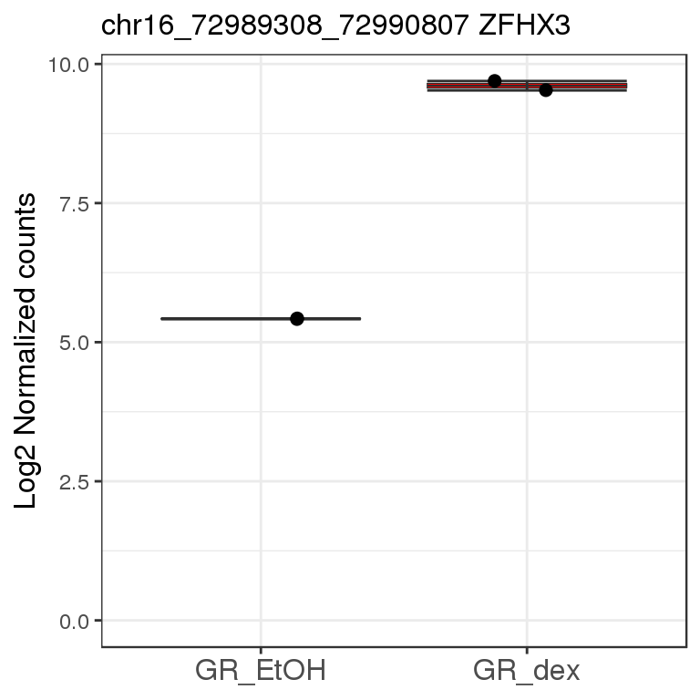

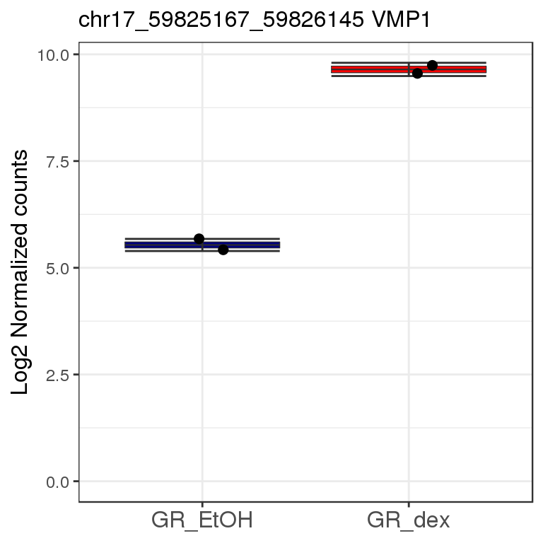

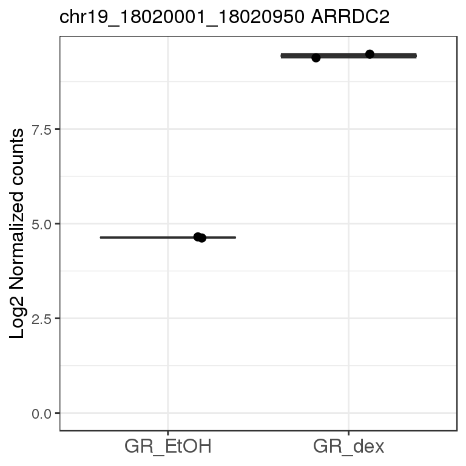

[8 more figures not shown]

### Profile of significant peaks binding to TSS regions

Heatmap of ChIP binding to TSS regions (left).

Average Profile of ChIP peaks binding to TSS region (right).

[output not shown]

[output not shown]

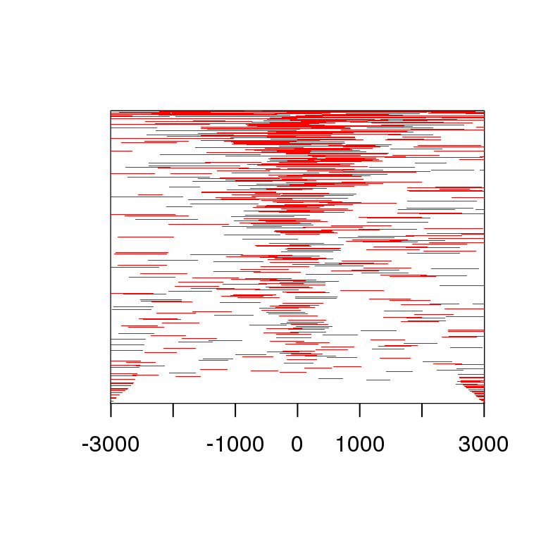

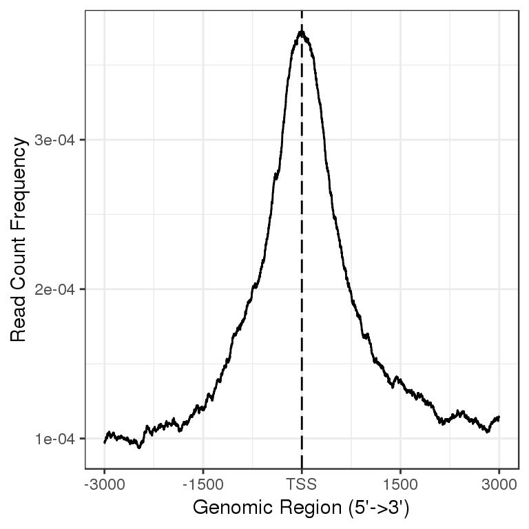

### Distribution of significant peaks’ genomic annotation

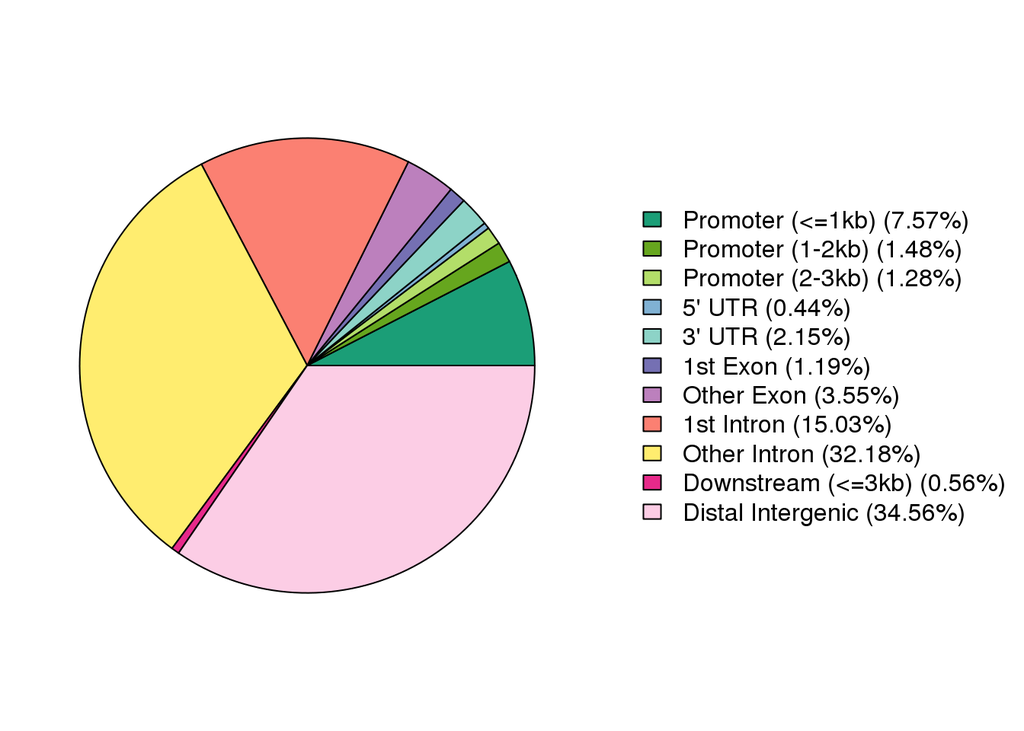

### Distribution of TF-binding loci relative to TSS

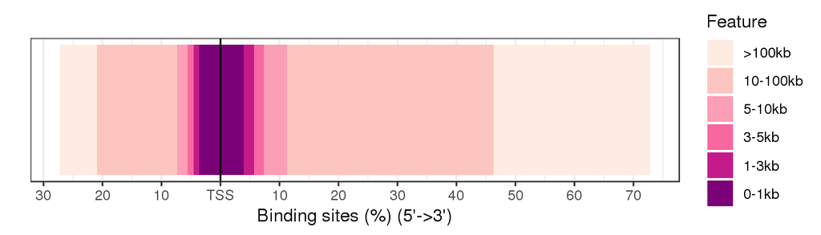

## RNAP2_dex vs. RNAP2_EtOH

### Samples in this comparison

Prepare diffbind csv input file

| SampleID | Tissue | Factor | Condition | Treatment | Replicate | bamReads | ControlID | bamControl | Peaks | PeakCaller |
| --- | --- | --- | --- | --- | --- | --- | --- | --- | --- | --- |
| SRR5309361 | ASM | RNAP2 | cond0 | EtOH | 1 | /home/mengykan/Projects/GSE95632/SRR5309361/bwa_out/SRR5309361.bam | SRR5309352 | /home/mengykan/Projects/GSE95632/SRR5309352/bwa_out/SRR5309352.bam | /home/mengykan/Projects/GSE95632/SRR5309361/macs2_out/SRR5309361.blackfilt.bed | bed |
| SRR5309362 | ASM | RNAP2 | cond0 | EtOH | 2 | /home/mengykan/Projects/GSE95632/SRR5309362/bwa_out/SRR5309362.bam | SRR5309352 | /home/mengykan/Projects/GSE95632/SRR5309352/bwa_out/SRR5309352.bam | /home/mengykan/Projects/GSE95632/SRR5309362/macs2_out/SRR5309362.blackfilt.bed | bed |
| SRR5309363 | ASM | RNAP2 | cond1 | Dex | 1 | /home/mengykan/Projects/GSE95632/SRR5309363/bwa_out/SRR5309363.bam | SRR5309355 | /home/mengykan/Projects/GSE95632/SRR5309355/bwa_out/SRR5309355.bam | /home/mengykan/Projects/GSE95632/SRR5309363/macs2_out/SRR5309363.blackfilt.bed | bed |
| SRR5309364 | ASM | RNAP2 | cond1 | Dex | 2 | /home/mengykan/Projects/GSE95632/SRR5309364/bwa_out/SRR5309364.bam | SRR5309355 | /home/mengykan/Projects/GSE95632/SRR5309355/bwa_out/SRR5309355.bam | /home/mengykan/Projects/GSE95632/SRR5309364/macs2_out/SRR5309364.blackfilt.bed | bed |

#### Major steps

1. Perform differential binding site analysis.
2. Annotate gene regions to peaks
3. Save differential results and count matrix for significant binding sites

### Top 50 differential binding sites by p-value

| Chr | Start | End | Conc | Fold | p.value | FDR | Annotation | Gene |
| --- | --- | --- | --- | --- | --- | --- | --- | --- |
| chr3 | 156673153 | 156726470 | 12.88 | 3.1 | 1.96e-146 | 2.62e-142 | Promoter | TIPARP |
| chr22 | 30238001 | 30249337 | 10.45 | -3.17 | 2.63e-119 | 1.76e-115 | Promoter | LIF |
| chr19 | 55363022 | 55371582 | 10.25 | -2.51 | 1.13e-72 | 5.07e-69 | Promoter | FAM71E2 |
| chrX | 107711904 | 107717442 | 8.77 | 2.99 | 3.65e-70 | 1.22e-66 | Promoter | TSC22D3 |
| chr7 | 45909349 | 45921661 | 9.6 | -2.56 | 5.54e-65 | 1.48e-61 | Promoter | IGFBP3 |
| chr17 | 34252464 | 34258401 | 8.75 | -2.71 | 1.29e-60 | 2.89e-57 | Promoter | CCL2 |
| chr10 | 44973990 | 44979156 | 9.51 | 2.17 | 1.15e-59 | 2.21e-56 | Promoter | DEPP1 |
| chr5 | 98787676 | 98797851 | 8.81 | -2.66 | 2.37e-59 | 3.96e-56 | 5' UTR | RGMB |
| chr1 | 182380472 | 182392734 | 9.9 | 2.06 | 6.14e-59 | 9.14e-56 | Promoter | GLUL |
| chr5 | 98768279 | 98787359 | 10.26 | -1.9 | 3.29e-57 | 4.41e-54 | Promoter | RGMB |

[output cut: 40 more lines]

### Description of annotated DiffBind output

Table above shows the selected columns. Here is the description of the full output:

| Output Column | Description |
| --- | --- |
| Chr | Chromosome of binding site |
| Start | Starting base position of binding site |
| End | End base position of binding site |
| Conc | Concentration - mean (log) reads across all samples in both groups |
| Conc_group1 | Group 1 Concentration - mean (log) reads across all samples first group |
| Conc_group2 | Group 2 Concentration - mean (log) reads across all samples in second group |
| Fold | Fold difference - mean fold difference of binding affinity of group 1 over group 2 (Conc1 - Conc2). |
| p.value | p-value calculation - statistic indicating significance of difference |
| FDR | adjusted p-value calculation - p-value subjected to multiple-testing correction |
| Annotation | Main type of genomic feature of the peak, including Promoter, 3' UTR, 5' UTR, Intron, Exon, Distal Intergenic, Downstream |

[output cut: 5 more lines]

### Volcano plots

Volcano plot (probes with a q-value <0.05 are present in red)

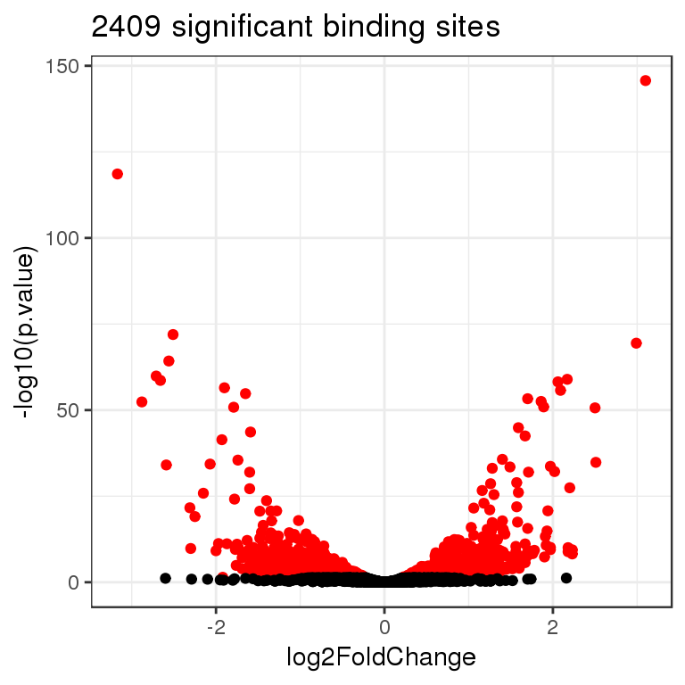

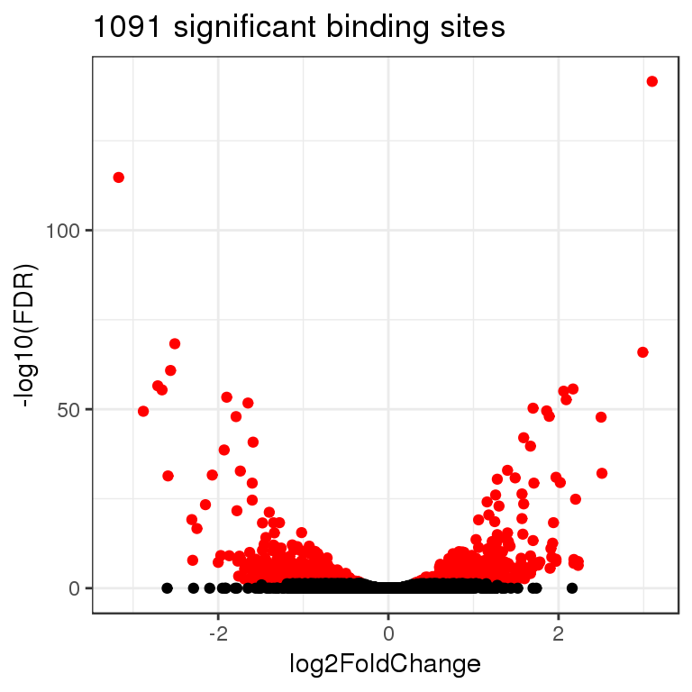

### MA plot

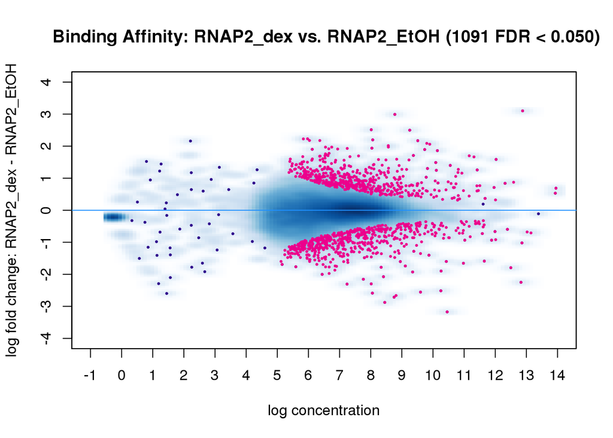

### Dendrogram based on log2 normalized data

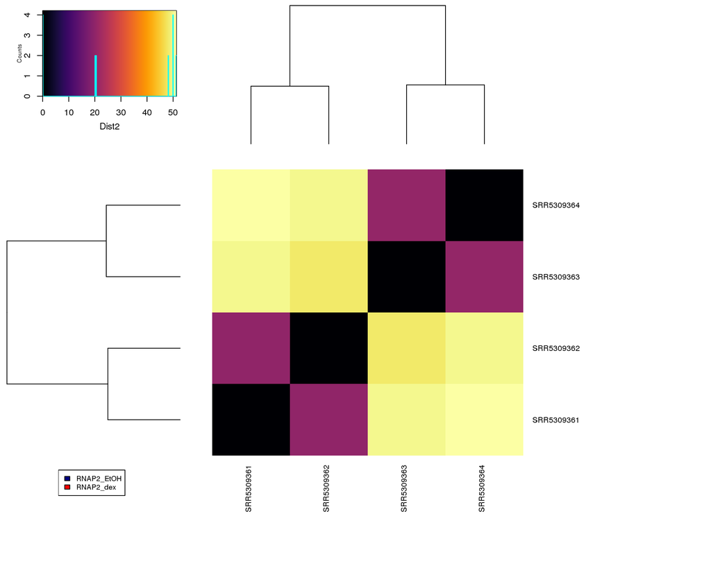

### Heatmaps for top 30 significant binding sites

Binding sites were ranked by adjusted p-values.

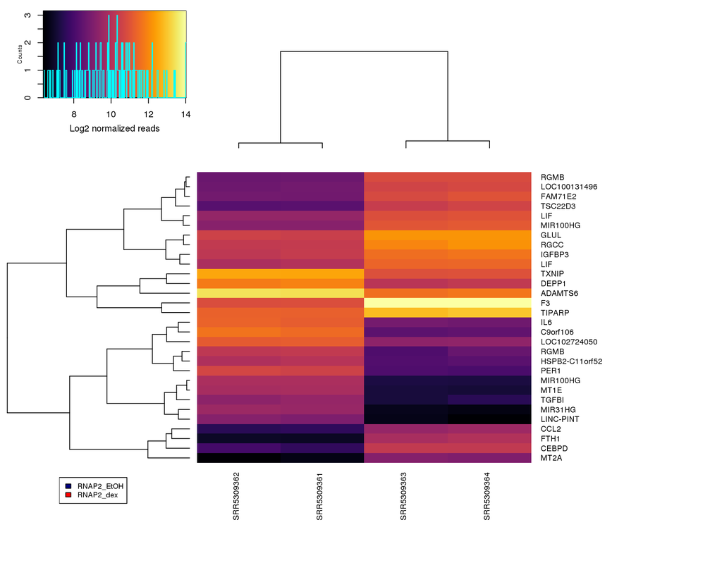

### Principal Component Analysis (PCA) Plot

Compute PCs and variance explained by the first 10 PCs

Variance explained

| PC | Proportion of Variance (%) | Cumulative Proportion of Variance (%) |
| --- | --- | --- |
| PC1 | 92.77 | 92.77 |
| PC2 | 7.031 | 99.8 |
| PC3 | 0.1178 | 99.91 |
| PC4 | 0.08527 | 100 |

PCA plots are generated using the first two principle components colored by known factors (e.g. Status, Tissue, or Donor)

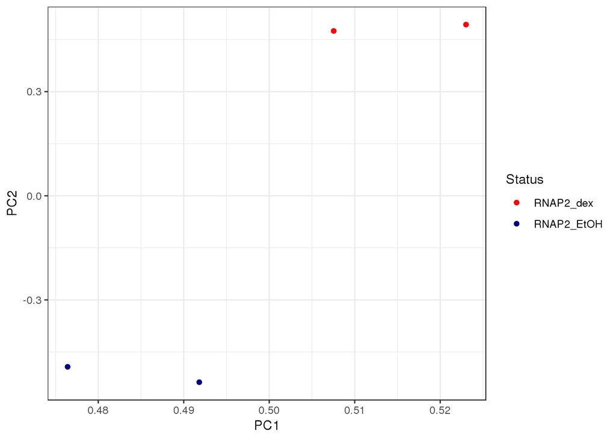